# Fantasy Football Projections: CMSC320 Final Tutorial

### Hypothesis Testing

The hypothesis test will be similar to the one conducted about quarterbacks and runningbacks. My question will be to see if I can predict a wide receiver's points in the next year based on their current years performance. I will one again try to see if I can fit a linear regression model on this data. The dependent variable will be the number of Fantasy Points a player will get in the next year, while the independent variables I hope to test will once again be all the attributes: 'Age', 'Games', 'GameStarted', 'Completions', 'PassingAttempts', 'PassingYards', 'InterceptionsThrown', 'RushingAttempts', 'RushingYards', 'Targets', 'Receptions', 'ReceivingYards', 'Yards per Reception', 'Fumbles', 'FumblesLost', 'PassingTD', 'RushingTD', 'ReceivingTD', 'Year'. I will be testing these attributes and whatever attributes are not significant, I will remove from the regression model. My *null hypothesis* will be that all of the attributes are insignificant (AKA there is no relationship between a certain attribute and a wide receiver's fantasy points in the next year), meaning if the coefficients in my linear regression model correpsonding to certain attributes have a p-value of 0.05 or less, I will reject the null hypothesis and use the attributes in my linear regression model. This means my *alternative hypothesis* would be that there does exist a relationship between a certain attribute and a wide receiver's fantasy points in the next year.

```python
widereciever_df_2 = widerecievers_df[['Player','Year']].copy()  # creating a dataframe with only year and fantasy points
widereciever_df_2['FutureFantasyPoints'] = widerecievers_df['FantasyPoints'].copy()
# for loop will subtract one from every year in the dataframe
new_years = []
for row in range(len(widereciever_df_2)):
    new_years.append(widereciever_df_2.iloc[row]['Year'] - 1)
widereciever_df_2['Year'] = new_years
widereciever_df_2 = widereciever_df_2[widereciever_df_2['Year'] > 1991].copy() # filter out 1991 data because I do not have any
widereciever_df_2.head()
```

|  | Player | Year | FutureFantasyPoints |
| --- | --- | --- | --- |
| 483 | Jerry Rice | 1992 | 345.20 |
| 486 | Andre Rison | 1992 | 296.20 |
| 490 | Sterling Sharpe | 1992 | 304.24 |
| 494 | Michael Irvin | 1992 | 263.60 |
| 500 | Cris Carter | 1992 | 247.10 |

Now that I have the Future Fantasy Points for every player, I will just add the column to the original wide reciever data frame. I will also remove players that do not have future fantasy points associated with them because they cannot be used to train or test my model.

```python
widerecievers_df = pd.merge(widerecievers_df, widereciever_df_2, on=['Year', 'Player'], how='right')
widerecievers_df.reset_index()
widerecievers_df.head()
```

|  | Player | Team | Position | Age | Games | GameStarted | Completions | PassingAttempts | PassingYards | InterceptionsThrown | ... | ReceivingYards | Yards per Reception | Fumbles | FumblesLost | PassingTD | RushingTD | ReceivingTD | FantasyPoints | Year | FutureFantasyPoints |
| --- | --- | --- | --- | --- | --- | --- | --- | --- | --- | --- | --- | --- | --- | --- | --- | --- | --- | --- | --- | --- | --- |
| 0 | Jerry Rice | SFO | WR | 30.0 | 16.0 | 16.0 | 0.0 | 0.0 | 0.0 | 0.0 | ... | 1201.0 | 14.30 | 2.0 | 0.0 | 0.0 | 1.0 | 10.0 | 271.9 | 1992 | 345.20 |
| 1 | Andre Rison | ATL | WR | 25.0 | 15.0 | 13.0 | 0.0 | 0.0 | 0.0 | 0.0 | ... | 1119.0 | 12.03 | 2.0 | 0.0 | 0.0 | 0.0 | 11.0 | 266.9 | 1992 | 296.20 |
| 2 | Sterling Sharpe | GNB | WR | 27.0 | 16.0 | 16.0 | 0.0 | 0.0 | 0.0 | 0.0 | ... | 1461.0 | 13.53 | 2.0 | 0.0 | 0.0 | 0.0 | 13.0 | 328.9 | 1992 | 304.24 |
| 3 | Michael Irvin | DAL | WR | 26.0 | 16.0 | 14.0 | 0.0 | 0.0 | 0.0 | 0.0 | ... | 1396.0 | 17.90 | 1.0 | 0.0 | 0.0 | 0.0 | 7.0 | 256.7 | 1992 | 263.60 |
| 4 | Cris Carter | MIN | WR | 27.0 | 12.0 | 12.0 | 0.0 | 0.0 | 0.0 | 0.0 | ... | 681.0 | 12.85 | 1.0 | 0.0 | 0.0 | 0.0 | 6.0 | 156.6 | 1992 | 247.10 |

5 rows × 24 columns

Now that my data frame is all good, I will once again try to use the previous attributes, but the dependent variable will be Future Fantasy Points instead of current Fantasy Points.

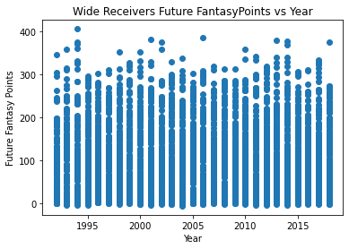

```python
# Plotting Future Fantasy Points of Wide Recievers during different years
plt.scatter(widerecievers_df["Year"], widerecievers_df["FutureFantasyPoints"])
plt.title("Wide Receivers Future FantasyPoints vs Year")
plt.xlabel("Year")
plt.ylabel("Future Fantasy Points")
plt.show()
```

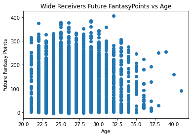

```python
# Plotting Future Fantasy Points of Wide Recievers versus age
plt.scatter(widerecievers_df["Age"], widerecievers_df["FutureFantasyPoints"])
plt.title("Wide Receivers Future FantasyPoints vs Age")
plt.xlabel("Age")
plt.ylabel("Future Fantasy Points")
plt.show()
```

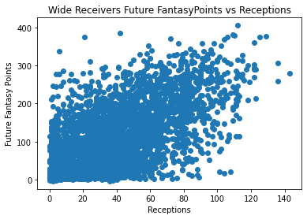

```python
# Plotting Future Fantasy Points of Wide Recievers versus Receptions
plt.scatter(widerecievers_df["Receptions"], widerecievers_df["FutureFantasyPoints"])
plt.title("Wide Receivers Future FantasyPoints vs Receptions")
plt.xlabel("Receptions")
plt.ylabel("Future Fantasy Points")
plt.show()
```

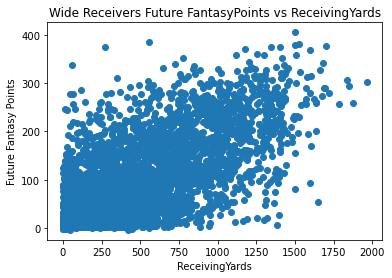

```python
# Plotting Future Fantasy Points of Wide Recievers versus ReceivingYards
plt.scatter(widerecievers_df["ReceivingYards"], widerecievers_df["FutureFantasyPoints"])
plt.title("Wide Receivers Future FantasyPoints vs ReceivingYards")
plt.xlabel("ReceivingYards")
plt.ylabel("Future Fantasy Points")
plt.show()
```

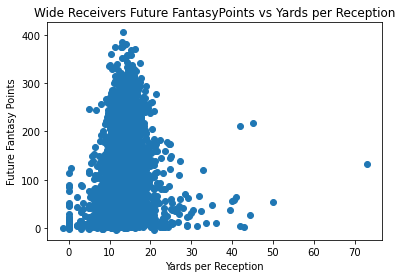

```python
# Plotting Future Fantasy Points of Wide Recievers versus Yards per Reception
plt.scatter(widerecievers_df["Yards per Reception"], widerecievers_df["FutureFantasyPoints"])
plt.title("Wide Receivers Future FantasyPoints vs Yards per Reception")
plt.xlabel("Yards per Reception")
plt.ylabel("Future Fantasy Points")
plt.show()
```

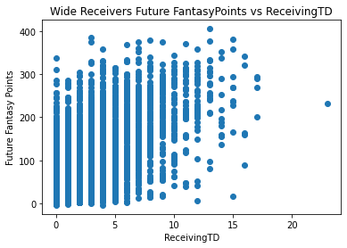

```python
# Plotting Future Fantasy Points of Wide Recievers versus receiving touch downs
plt.scatter(widerecievers_df["ReceivingTD"], widerecievers_df["FutureFantasyPoints"])
plt.title("Wide Receivers Future FantasyPoints vs ReceivingTD")
plt.xlabel("ReceivingTD")
plt.ylabel("Future Fantasy Points")
plt.show()
```

All of the attributes seem to have pretty similar correlations with the Future Fantasy Points as they did with the current fantasy points. The main difference is just that the linear relationship is much stronger between the current Fantasy Points versus the Receptions and Receiving Yards than they are with the future fantasy points versus receptions and receiving yards. The yards per reception still has the property that no matter what the player's fantasy points, the majority of people's yards per reception is between 10 and 20.  
Now let's create our training and testing sets.

```python
# Before getting into the actual testing phase I must first split the data into training and testing sets
widerecievers_df = widerecievers_df.dropna() # drop rows without data
X_one = widerecievers_df[['Age', 'Games', 'GameStarted', 'Completions', 'PassingAttempts', 'PassingYards', 'InterceptionsThrown', 'RushingAttempts', 'RushingYards', 'Targets', 'Receptions', 'ReceivingYards', 'Yards per Reception', 'Fumbles', 'FumblesLost', 'PassingTD', 'RushingTD', 'ReceivingTD', 'Year']]
Y_one = widerecievers_df['FutureFantasyPoints']
X_one = sm.add_constant(X_one)
ind_train, ind_test, dep_train, dep_test = ms.train_test_split(X_one, Y_one, random_state=42)
print(len(ind_train), len(ind_test))
```

```
2566 856
```

```python
fit = sm.OLS(dep_train, ind_train).fit()
fit.summary()

# source: https://machinelearningmind.com/2019/10/14/feature-elimination-using-p-values/
```

OLS Regression Results

| Dep. Variable: | FutureFantasyPoints | R-squared: | 0.457 |
| --- | --- | --- | --- |
| Model: | OLS | Adj. R-squared: | 0.453 |
| Method: | Least Squares | F-statistic: | 112.7 |
| Date: | Sun, 15 May 2022 | Prob (F-statistic): | 8.91e-320 |
| Time: | 18:50:54 | Log-Likelihood: | -14275. |
| No. Observations: | 2566 | AIC: | 2.859e+04 |
| Df Residuals: | 2546 | BIC: | 2.871e+04 |
| Df Model: | 19 |  |  |
| Covariance Type: | nonrobust |  |  |

|  | coef | std err | t | P>\|t\| | [0.025 | 0.975] |
| --- | --- | --- | --- | --- | --- | --- |
| const | 678.2788 | 345.907 | 1.961 | 0.050 | -0.010 | 1356.567 |
| Age | -2.5780 | 0.426 | -6.052 | 0.000 | -3.413 | -1.743 |
| Games | -3.4462 | 0.420 | -8.208 | 0.000 | -4.269 | -2.623 |
| GameStarted | -0.0427 | 0.436 | -0.098 | 0.922 | -0.898 | 0.812 |
| Completions | -3.5006 | 10.346 | -0.338 | 0.735 | -23.788 | 16.787 |
| PassingAttempts | 1.6539 | 5.743 | 0.288 | 0.773 | -9.608 | 12.916 |
| PassingYards | 0.1757 | 0.338 | 0.520 | 0.603 | -0.487 | 0.838 |
| InterceptionsThrown | 25.8682 | 18.456 | 1.402 | 0.161 | -10.322 | 62.058 |
| RushingAttempts | -1.3621 | 0.666 | -2.045 | 0.041 | -2.668 | -0.056 |
| RushingYards | 0.2138 | 0.100 | 2.135 | 0.033 | 0.017 | 0.410 |
| Targets | 0.1146 | 0.146 | 0.785 | 0.433 | -0.172 | 0.401 |
| Receptions | 0.4787 | 0.256 | 1.870 | 0.062 | -0.023 | 0.981 |
| ReceivingYards | 0.0943 | 0.016 | 5.898 | 0.000 | 0.063 | 0.126 |
| Yards per Reception | 0.0994 | 0.362 | 0.274 | 0.784 | -0.611 | 0.810 |
| Fumbles | 3.4214 | 1.497 | 2.285 | 0.022 | 0.486 | 6.357 |
| FumblesLost | -3.0831 | 2.489 | -1.239 | 0.216 | -7.963 | 1.797 |
| PassingTD | 1.9192 | 14.214 | 0.135 | 0.893 | -25.953 | 29.792 |
| RushingTD | 1.2474 | 6.425 | 0.194 | 0.846 | -11.351 | 13.846 |
| ReceivingTD | 3.0416 | 0.681 | 4.466 | 0.000 | 1.706 | 4.377 |
| Year | -0.2716 | 0.171 | -1.584 | 0.113 | -0.608 | 0.065 |

| Omnibus: | 85.450 | Durbin-Watson: | 1.892 |
| --- | --- | --- | --- |
| Prob(Omnibus): | 0.000 | Jarque-Bera (JB): | 103.539 |
| Skew: | 0.392 | Prob(JB): | 3.29e-23 |
| Kurtosis: | 3.595 | Cond. No. | 5.75e+05 |

Notes:  
[1] Standard Errors assume that the covariance matrix of the errors is correctly specified.  
[2] The condition number is large, 5.75e+05. This might indicate that there are  
strong multicollinearity or other numerical problems.

From the chart above, it appears that the only attributes that are significant are 'Age', 'Games', 'RushingAttempts', 'RushingYards', 'ReceivingYards', 'Fumbles', and 'ReceivingTD'.  
I will now create a new regression model using only these attributes.

```python
# Before getting into the actual testing phase I must first split the data into training and testing sets
widerecievers_df = widerecievers_df.dropna() # drop rows without data
X_one = widerecievers_df[['Age', 'Games', 'RushingAttempts', 'RushingYards', 'ReceivingYards', 'Fumbles', 'ReceivingTD']]
Y_one = widerecievers_df['FutureFantasyPoints']
X_one = sm.add_constant(X_one)
ind_train, ind_test, dep_train, dep_test = ms.train_test_split(X_one, Y_one, random_state=42)
print(len(ind_train), len(ind_test))
```

```
2566 856
```

```python
fit = sm.OLS(dep_train, ind_train).fit()
fit.summary()

# source: https://machinelearningmind.com/2019/10/14/feature-elimination-using-p-values/
```

OLS Regression Results

| Dep. Variable: | FutureFantasyPoints | R-squared: | 0.453 |
| --- | --- | --- | --- |
| Model: | OLS | Adj. R-squared: | 0.451 |
| Method: | Least Squares | F-statistic: | 302.1 |
| Date: | Sun, 15 May 2022 | Prob (F-statistic): | 0.00 |
| Time: | 19:06:34 | Log-Likelihood: | -14285. |
| No. Observations: | 2566 | AIC: | 2.859e+04 |
| Df Residuals: | 2558 | BIC: | 2.863e+04 |
| Df Model: | 7 |  |  |
| Covariance Type: | nonrobust |  |  |

|  | coef | std err | t | P>\|t\| | [0.025 | 0.975] |
| --- | --- | --- | --- | --- | --- | --- |
| const | 127.0727 | 11.309 | 11.236 | 0.000 | 104.896 | 149.249 |
| Age | -2.2895 | 0.414 | -5.530 | 0.000 | -3.101 | -1.478 |
| Games | -3.2366 | 0.412 | -7.861 | 0.000 | -4.044 | -2.429 |
| RushingAttempts | -1.2292 | 0.661 | -1.859 | 0.063 | -2.526 | 0.067 |
| RushingYards | 0.2177 | 0.094 | 2.320 | 0.020 | 0.034 | 0.402 |
| ReceivingYards | 0.1390 | 0.006 | 23.376 | 0.000 | 0.127 | 0.151 |
| Fumbles | 2.4743 | 1.077 | 2.298 | 0.022 | 0.363 | 4.586 |
| ReceivingTD | 2.9005 | 0.680 | 4.268 | 0.000 | 1.568 | 4.233 |

| Omnibus: | 94.256 | Durbin-Watson: | 1.896 |
| --- | --- | --- | --- |
| Prob(Omnibus): | 0.000 | Jarque-Bera (JB): | 114.212 |
| Skew: | 0.419 | Prob(JB): | 1.58e-25 |
| Kurtosis: | 3.605 | Cond. No. | 6.00e+03 |

Notes:  
[1] Standard Errors assume that the covariance matrix of the errors is correctly specified.  
[2] The condition number is large, 6e+03. This might indicate that there are  
strong multicollinearity or other numerical problems.

It appears everything is significant except RushingAttempts because RushingAttempts now has a p-value that is above 0.05, so I will have to create a new regression model with all the current attributes except RushingAttempts.

```python
# Before getting into the actual testing phase I must first split the data into training and testing sets
widerecievers_df = widerecievers_df.dropna() # drop rows without data
X_one = widerecievers_df[['Age', 'Games', 'RushingYards', 'ReceivingYards', 'Fumbles', 'ReceivingTD']]
Y_one = widerecievers_df['FutureFantasyPoints']
X_one = sm.add_constant(X_one)
ind_train, ind_test, dep_train, dep_test = ms.train_test_split(X_one, Y_one, random_state=42)
print(len(ind_train), len(ind_test))
```

```
2566 856
```

```python
fit = sm.OLS(dep_train, ind_train).fit()
fit.summary()

# source: https://machinelearningmind.com/2019/10/14/feature-elimination-using-p-values/
```

OLS Regression Results

| Dep. Variable: | FutureFantasyPoints | R-squared: | 0.452 |
| --- | --- | --- | --- |
| Model: | OLS | Adj. R-squared: | 0.451 |
| Method: | Least Squares | F-statistic: | 351.6 |
| Date: | Sun, 15 May 2022 | Prob (F-statistic): | 0.00 |
| Time: | 19:07:53 | Log-Likelihood: | -14287. |
| No. Observations: | 2566 | AIC: | 2.859e+04 |
| Df Residuals: | 2559 | BIC: | 2.863e+04 |
| Df Model: | 6 |  |  |
| Covariance Type: | nonrobust |  |  |

|  | coef | std err | t | P>\|t\| | [0.025 | 0.975] |
| --- | --- | --- | --- | --- | --- | --- |
| const | 126.8653 | 11.314 | 11.213 | 0.000 | 104.680 | 149.051 |
| Age | -2.2867 | 0.414 | -5.521 | 0.000 | -3.099 | -1.474 |
| Games | -3.2456 | 0.412 | -7.880 | 0.000 | -4.053 | -2.438 |
| RushingYards | 0.0658 | 0.046 | 1.424 | 0.154 | -0.025 | 0.156 |
| ReceivingYards | 0.1390 | 0.006 | 23.367 | 0.000 | 0.127 | 0.151 |
| Fumbles | 2.2111 | 1.068 | 2.070 | 0.039 | 0.117 | 4.305 |
| ReceivingTD | 2.8878 | 0.680 | 4.248 | 0.000 | 1.555 | 4.221 |

| Omnibus: | 96.386 | Durbin-Watson: | 1.897 |
| --- | --- | --- | --- |
| Prob(Omnibus): | 0.000 | Jarque-Bera (JB): | 116.840 |
| Skew: | 0.425 | Prob(JB): | 4.25e-26 |
| Kurtosis: | 3.607 | Cond. No. | 6.00e+03 |

Notes:  
[1] Standard Errors assume that the covariance matrix of the errors is correctly specified.  
[2] The condition number is large, 6e+03. This might indicate that there are  
strong multicollinearity or other numerical problems.

Now rushing yards is not significant, so I will have to do the same steps without rushing yards.

```python
# Before getting into the actual testing phase I must first split the data into training and testing sets
widerecievers_df = widerecievers_df.dropna() # drop rows without data
X_one = widerecievers_df[['Age', 'Games', 'ReceivingYards', 'Fumbles', 'ReceivingTD']]
Y_one = widerecievers_df['FutureFantasyPoints']
X_one = sm.add_constant(X_one)
ind_train, ind_test, dep_train, dep_test = ms.train_test_split(X_one, Y_one, random_state=42)
print(len(ind_train), len(ind_test))
```

```
2566 856
```

```python
fit = sm.OLS(dep_train, ind_train).fit()
fit.summary()

# source: https://machinelearningmind.com/2019/10/14/feature-elimination-using-p-values/
```

OLS Regression Results

| Dep. Variable: | FutureFantasyPoints | R-squared: | 0.451 |
| --- | --- | --- | --- |
| Model: | OLS | Adj. R-squared: | 0.450 |
| Method: | Least Squares | F-statistic: | 421.3 |
| Date: | Sun, 15 May 2022 | Prob (F-statistic): | 0.00 |
| Time: | 19:08:46 | Log-Likelihood: | -14288. |
| No. Observations: | 2566 | AIC: | 2.859e+04 |
| Df Residuals: | 2560 | BIC: | 2.862e+04 |
| Df Model: | 5 |  |  |
| Covariance Type: | nonrobust |  |  |

|  | coef | std err | t | P>\|t\| | [0.025 | 0.975] |
| --- | --- | --- | --- | --- | --- | --- |
| const | 127.8328 | 11.296 | 11.317 | 0.000 | 105.683 | 149.983 |
| Age | -2.3276 | 0.413 | -5.632 | 0.000 | -3.138 | -1.517 |
| Games | -3.2120 | 0.411 | -7.810 | 0.000 | -4.018 | -2.405 |
| ReceivingYards | 0.1394 | 0.006 | 23.456 | 0.000 | 0.128 | 0.151 |
| Fumbles | 2.4180 | 1.058 | 2.285 | 0.022 | 0.343 | 4.493 |
| ReceivingTD | 2.8793 | 0.680 | 4.235 | 0.000 | 1.546 | 4.213 |

| Omnibus: | 96.900 | Durbin-Watson: | 1.899 |
| --- | --- | --- | --- |
| Prob(Omnibus): | 0.000 | Jarque-Bera (JB): | 116.855 |
| Skew: | 0.429 | Prob(JB): | 4.22e-26 |
| Kurtosis: | 3.597 | Cond. No. | 5.99e+03 |

Notes:  
[1] Standard Errors assume that the covariance matrix of the errors is correctly specified.  
[2] The condition number is large, 5.99e+03. This might indicate that there are  
strong multicollinearity or other numerical problems.

Now it finally appears that all of the tested attributes are significant, so I now have my final regression model for predicting how well a Wide Receiver will perform in the following year based on their current year's performance.  
The model is:  
FutureFantasyPoints = 127.83 - 2.3276 x age - 3.212 x games + 0.1394 x receivingyards + 2.418 x fumbles + 2.879 x receivingtd  
This model shows that once again age and games played negatively impact future performance, while the other attributes that are significant positively impact the future performance. In this case it is the receiving yards, fumbles, and receiving touch downs that positively impact the player's performance.  
Now let's test this regression model on the testing set. We already know that for the training data, the model has an R-squared score of 0.451. This means that 45.1 percent of the variance in the dependent variable is explained by the model for the training data.

### Insights

```python
predicted = fit.predict(ind_test)
```

Now similarly to last time, now that we have the predictions of the depedent variables based off of the independent variables from the test set, we can compare it with the actual values of the dependent variable from the test set. We will still look at all three tests.  
Source: https://towardsdatascience.com/linear-regression-in-python-9a1f5f000606

```python
# Mean absolute error
met.mean_absolute_error(predicted, dep_test)
```

```
51.47826897995666
```

```python
# Mean squared error
met.mean_squared_error(predicted, dep_test)
```

```
4260.121817362692
```

```python
# Root mean absolute error
np.sqrt(met.mean_squared_error(predicted, dep_test))
```

```
65.26960868093735
```

Based on the above metrics, the mean absolute error means that on average the actual fantasy points a player gets in a following year is 51.48 points away from what the linear regression model predicts for the test set. Since the root mean absolute error is greater than the mean absolute error, this means that the data is concentrated away from the linear regression model. This means that while the linear regression model somewhat fits the data, and all of the coefficients and attributes used are significant for the model, the model is still not able to very accurately predict how well a wide receiver will perform based on his previous year's performance.

## Wrap up Thoughts

Looking at the models I created, there were a lot of similarities, such as the fact that age and games played always seemed to negatively impact performance, while the other attributes that were deemed significant always seemed to help the future fantasy points. In general, none of my models were all that accurate, but it is difficult to come up with an accurate model for this type of sport anyways because everyone is different and just because two people play the same position does not mean they will improve at the same rate based on their statistics. Also football is a very dangerous sport, and players are always getting injured. As a result, players who may perform very well during a previous year may not perform as well in a future year due to being injured. I tried to take these injury variables into account by attempting to factor in age, but just because a player is older than another player, it does not necessarily mean they are more prone to injury, it all depends on other factors. Maybe I could have created more accurate models if I had more statistics about different players, but that is just a way this tutorial can be improved upon in the future.  
Besides that though, I felt like this was very enlightening to see how the model deemed certain features to be insignificant, when I really assumed they would have played a large role. For example, I would have thought Yards per Reception and Reception would have played a more vital role for predicting future performances of Wide Receivers, but it actually did not pan out to be significant, which really surprised me because they play such a vital role in a wide receiver's job in the sport.  
I will love to see how these models pan out when I play fantasy next year though!